# Tubes_Statistik

Kaenova Mahendra Auditama<sup>1</sup> (1301190324)  
Rachdian Habi Yahya<sup>2</sup> (1301193293)  
Fendi Irfan Amorokhman<sup>3</sup> (1301191447)  
Arya Pangestu<sup>4</sup> (1301190144)  
<sup>1</sup>kaenova@student.telkomuniversity.ac.id  
<sup>2</sup>rhabiy@student.telkomuniversity.ac.id  
<sup>3</sup>fendiirfan@student.telkomuniversity.ac.id  
<sup>4</sup>aryapangestu@student.telkomuniversity.ac.id  
CII1C2-IF-43-GAB05  
Group X  
Informatics Engineering, Telkom University, Indonesia  
2020

### Research Question, Method, and Prediction

### 1. Research Question

Orang dengan ciri-ciri seperti apa dari data yang diberikan saat ini dengan utilisasi yang di bawah rata-rata?

### 2. Method

Method yang akan digunakan adalah Statistika Deskriptif, dimana kita akan mengolah data yang sudah diberikan sehingga dapat memberikan informasi yang baru

### 3. Prediction

Menurut saya, kita akan membutuhkan data ciri-ciri orang-orang tersebut. Sehingga dapat terlihat pola yang ada dengan metode-metode statistika. Prediksi saya orang-orang yang tidak mengutilisasikan kredit tersebut merupakan orang-orang yang dari data memiliki Income yang kurang.

### Installing Packages and Load Packages

```r
install.packages("summarytools", repos = 'https://cloud.r-project.org/')
install.packages("dplyr", repos = 'https://cloud.r-project.org/')
install.packages("repr", repos = 'https://cloud.r-project.org/')
install.packages("DataExplorer", repos = 'https://cloud.r-project.org/')
require("summarytools")
require("dplyr")
require("repr")
require("DataExplorer")
```

### Importing Data Frame

```r
df <- read.csv("./BankChurners.csv")
head(df)
descr(df)
```

A data.frame: 6 × 23

|  | CLIENTNUM <int> | Attrition_Flag <chr> | Customer_Age <int> | Gender <chr> | Dependent_count <int> | Education_Level <chr> | Marital_Status <chr> | Income_Category <chr> | Card_Category <chr> | Months_on_book <int> | ... | Credit_Limit <dbl> | Total_Revolving_Bal <int> | Avg_Open_To_Buy <dbl> | Total_Amt_Chng_Q4_Q1 <dbl> | Total_Trans_Amt <int> | Total_Trans_Ct <int> | Total_Ct_Chng_Q4_Q1 <dbl> | Avg_Utilization_Ratio <dbl> | Naive_Bayes_Classifier_Attrition_Flag_Card_Category_Contacts_Count_12_mon_Dependent_count_Education_Level_Months_Inactive_12_mon_1 <dbl> | Naive_Bayes_Classifier_Attrition_Flag_Card_Category_Contacts_Count_12_mon_Dependent_count_Education_Level_Months_Inactive_12_mon_2 <dbl> |
| --- | --- | --- | --- | --- | --- | --- | --- | --- | --- | --- | --- | --- | --- | --- | --- | --- | --- | --- | --- | --- | --- |
| 1 | 768805383 | Existing Customer | 45 | M | 3 | High School | Married | $60K - $80K | Blue | 39 | ... | 12691 | 777 | 11914 | 1.335 | 1144 | 42 | 1.625 | 0.061 | 9.3448e-05 | 0.99991 |
| 2 | 818770008 | Existing Customer | 49 | F | 5 | Graduate | Single | Less than $40K | Blue | 44 | ... | 8256 | 864 | 7392 | 1.541 | 1291 | 33 | 3.714 | 0.105 | 5.6861e-05 | 0.99994 |
| 3 | 713982108 | Existing Customer | 51 | M | 3 | Graduate | Married | $80K - $120K | Blue | 36 | ... | 3418 | 0 | 3418 | 2.594 | 1887 | 20 | 2.333 | 0.000 | 2.1081e-05 | 0.99998 |
| 4 | 769911858 | Existing Customer | 40 | F | 4 | High School | Unknown | Less than $40K | Blue | 34 | ... | 3313 | 2517 | 796 | 1.405 | 1171 | 20 | 2.333 | 0.760 | 1.3366e-04 | 0.99987 |
| 5 | 709106358 | Existing Customer | 40 | M | 3 | Uneducated | Married | $60K - $80K | Blue | 21 | ... | 4716 | 0 | 4716 | 2.175 | 816 | 28 | 2.500 | 0.000 | 2.1676e-05 | 0.99998 |
| 6 | 713061558 | Existing Customer | 44 | M | 2 | Graduate | Married | $40K - $60K | Blue | 36 | ... | 4010 | 1247 | 2763 | 1.376 | 1088 | 24 | 0.846 | 0.311 | 5.5077e-05 | 0.99994 |

A summarytools: 15 × 17 of type dbl

|  | Avg_Open_To_Buy | Avg_Utilization_Ratio | CLIENTNUM | Contacts_Count_12_mon | Credit_Limit | Customer_Age | Dependent_count | Months_Inactive_12_mon | Months_on_book | Naive_Bayes_Classifier_Attrition_Flag_Card_Category_Contacts_Count_12_mon_Dependent_count_Education_Level_Months_Inactive_12_mon_1 | Naive_Bayes_Classifier_Attrition_Flag_Card_Category_Contacts_Count_12_mon_Dependent_count_Education_Level_Months_Inactive_12_mon_2 | Total_Amt_Chng_Q4_Q1 | Total_Ct_Chng_Q4_Q1 | Total_Relationship_Count | Total_Revolving_Bal | Total_Trans_Amt | Total_Trans_Ct |
| --- | --- | --- | --- | --- | --- | --- | --- | --- | --- | --- | --- | --- | --- | --- | --- | --- | --- |
| Mean | 7.469140e+03 | 2.748936e-01 | 7.391776e+08 | 2.455317e+00 | 8.631954e+03 | 4.632596e+01 | 2.346203e+00 | 2.341167e+00 | 3.592841e+01 | 1.599975e-01 | 8.400026e-01 | 7.599407e-01 | 7.122224e-01 | 3.812580e+00 | 1.162814e+03 | 4.404086e+03 | 6.485869e+01 |
| Std.Dev | 9.090685e+03 | 2.756915e-01 | 3.690378e+07 | 1.106225e+00 | 9.088777e+03 | 8.016814e+00 | 1.298908e+00 | 1.010622e+00 | 7.986416e+00 | 3.653010e-01 | 3.653010e-01 | 2.192068e-01 | 2.380861e-01 | 1.554408e+00 | 8.149873e+02 | 3.397129e+03 | 2.347257e+01 |
| Min | 3.000000e+00 | 0.000000e+00 | 7.080821e+08 | 0.000000e+00 | 1.438300e+03 | 2.600000e+01 | 0.000000e+00 | 0.000000e+00 | 1.300000e+01 | 7.664200e-06 | 4.199800e-04 | 0.000000e+00 | 0.000000e+00 | 1.000000e+00 | 0.000000e+00 | 5.100000e+02 | 1.000000e+01 |
| Q1 | 1.324000e+03 | 2.300000e-02 | 7.130362e+08 | 2.000000e+00 | 2.555000e+03 | 4.100000e+01 | 1.000000e+00 | 2.000000e+00 | 3.100000e+01 | 9.898300e-05 | 9.996600e-01 | 6.310000e-01 | 5.820000e-01 | 3.000000e+00 | 3.570000e+02 | 2.155000e+03 | 4.500000e+01 |
| Median | 3.474000e+03 | 1.760000e-01 | 7.179264e+08 | 2.000000e+00 | 4.549000e+03 | 4.600000e+01 | 2.000000e+00 | 2.000000e+00 | 3.600000e+01 | 1.814600e-04 | 9.998200e-01 | 7.360000e-01 | 7.020000e-01 | 4.000000e+00 | 1.276000e+03 | 3.899000e+03 | 6.700000e+01 |
| Q3 | 9.861000e+03 | 5.030000e-01 | 7.731464e+08 | 3.000000e+00 | 1.106800e+04 | 5.200000e+01 | 3.000000e+00 | 3.000000e+00 | 4.000000e+01 | 3.373000e-04 | 9.999000e-01 | 8.590000e-01 | 8.180000e-01 | 5.000000e+00 | 1.784000e+03 | 4.741000e+03 | 8.100000e+01 |
| Max | 3.451600e+04 | 9.990000e-01 | 8.283431e+08 | 6.000000e+00 | 3.451600e+04 | 7.300000e+01 | 5.000000e+00 | 6.000000e+00 | 5.600000e+01 | 9.995800e-01 | 9.999900e-01 | 3.397000e+00 | 3.714000e+00 | 6.000000e+00 | 2.517000e+03 | 1.848400e+04 | 1.390000e+02 |
| MAD | 3.951129e+03 | 2.609376e-01 | 9.411100e+06 | 1.482600e+00 | 3.844382e+03 | 8.895600e+00 | 1.482600e+00 | 1.482600e+00 | 5.930400e+00 | 1.634329e-04 | 1.630860e-04 | 1.690164e-01 | 1.764294e-01 | 1.482600e+00 | 8.762166e+02 | 1.939241e+03 | 2.520420e+01 |
| IQR | 8.534500e+03 | 4.800000e-01 | 6.010676e+07 | 1.000000e+00 | 8.512500e+03 | 1.100000e+01 | 2.000000e+00 | 1.000000e+00 | 9.000000e+00 | 2.383170e-04 | 2.400000e-04 | 2.280000e-01 | 2.360000e-01 | 2.000000e+00 | 1.425000e+03 | 2.585500e+03 | 3.600000e+01 |
| CV | 1.217099e+00 | 1.002903e+00 | 4.992546e-02 | 4.505426e-01 | 1.052922e+00 | 1.730523e-01 | 5.536214e-01 | 4.316746e-01 | 2.222869e-01 | 2.283168e+00 | 4.348809e-01 | 2.884525e-01 | 3.342862e-01 | 4.077050e-01 | 7.008750e-01 | 7.713585e-01 | 3.619032e-01 |
| Skewness | 1.661204e+00 | 7.177953e-01 | 9.953061e-01 | 1.100237e-02 | 1.666232e+00 | -3.359506e-02 | -2.081937e-02 | 6.328736e-01 | -1.065338e-01 | 1.847991e+00 | -1.847991e+00 | 1.731550e+00 | 2.063419e+00 | -1.624043e-01 | -1.487932e-01 | 2.040399e+00 | 1.536275e-01 |
| SE.Skewness | 2.433722e-02 | 2.433722e-02 | 2.433722e-02 | 2.433722e-02 | 2.433722e-02 | 2.433722e-02 | 2.433722e-02 | 2.433722e-02 | 2.433722e-02 | 2.433722e-02 | 2.433722e-02 | 2.433722e-02 | 2.433722e-02 | 2.433722e-02 | 2.433722e-02 | 2.433722e-02 | 2.433722e-02 |
| Kurtosis | 1.796190e+00 | -7.956073e-01 | -6.163990e-01 | -3.226859e-04 | 1.806554e+00 | -2.896052e-01 | -6.837294e-01 | 1.096579e+00 | 3.986389e-01 | 1.415371e+00 | 1.415371e+00 | 9.985410e+00 | 1.567727e+01 | -1.006620e+00 | -1.146385e+00 | 3.890148e+00 | -3.680943e-01 |
| N.Valid | 1.012700e+04 | 1.012700e+04 | 1.012700e+04 | 1.012700e+04 | 1.012700e+04 | 1.012700e+04 | 1.012700e+04 | 1.012700e+04 | 1.012700e+04 | 1.012700e+04 | 1.012700e+04 | 1.012700e+04 | 1.012700e+04 | 1.012700e+04 | 1.012700e+04 | 1.012700e+04 | 1.012700e+04 |
| Pct.Valid | 1.000000e+02 | 1.000000e+02 | 1.000000e+02 | 1.000000e+02 | 1.000000e+02 | 1.000000e+02 | 1.000000e+02 | 1.000000e+02 | 1.000000e+02 | 1.000000e+02 | 1.000000e+02 | 1.000000e+02 | 1.000000e+02 | 1.000000e+02 | 1.000000e+02 | 1.000000e+02 | 1.000000e+02 |

### Data Wrangling

```r
#Memindahkan ke dataframe baru
wr <- data.frame("Status_Pelanggan" = df$Attrition_Flag,
                 "Waktu_Buku" = df$Months_on_book,
                 "Umur_Pengguna" = df$Customer_Age,
                 "Jenis_Kelamin" = df$Gender,
                 "Jenis_Kartu" = df$Card_Category,
                 "Tingkat_Pendidikan" = df$Education_Level,
                 "Status_Pernikahan" = df$Marital_Status,
                 "Penghasilan" = df$Income_Category,
                 "Limit_Kredit" = df$Credit_Limit,
                 "Besar_Transaksi" = df$Total_Trans_Amt,
                 "Banyak_Transaksi" = df$Total_Trans_Ct,
                 "Utilisasi" = df$Avg_Utilization_Ratio)
head(wr)
```

A data.frame: 6 × 12

|  | Status_Pelanggan <chr> | Waktu_Buku <int> | Umur_Pengguna <int> | Jenis_Kelamin <chr> | Jenis_Kartu <chr> | Tingkat_Pendidikan <chr> | Status_Pernikahan <chr> | Penghasilan <chr> | Limit_Kredit <dbl> | Besar_Transaksi <int> | Banyak_Transaksi <int> | Utilisasi <dbl> |
| --- | --- | --- | --- | --- | --- | --- | --- | --- | --- | --- | --- | --- |
| 1 | Existing Customer | 39 | 45 | M | Blue | High School | Married | $60K - $80K | 12691 | 1144 | 42 | 0.061 |
| 2 | Existing Customer | 44 | 49 | F | Blue | Graduate | Single | Less than $40K | 8256 | 1291 | 33 | 0.105 |
| 3 | Existing Customer | 36 | 51 | M | Blue | Graduate | Married | $80K - $120K | 3418 | 1887 | 20 | 0.000 |
| 4 | Existing Customer | 34 | 40 | F | Blue | High School | Unknown | Less than $40K | 3313 | 1171 | 20 | 0.760 |
| 5 | Existing Customer | 21 | 40 | M | Blue | Uneducated | Married | $60K - $80K | 4716 | 816 | 28 | 0.000 |
| 6 | Existing Customer | 36 | 44 | M | Blue | Graduate | Married | $40K - $60K | 4010 | 1088 | 24 | 0.311 |

### Data Exploration

Pertama, kita harus tahu keterhubungan antara jenis kartu yang dipakai dan utilisasi kartu tersebut

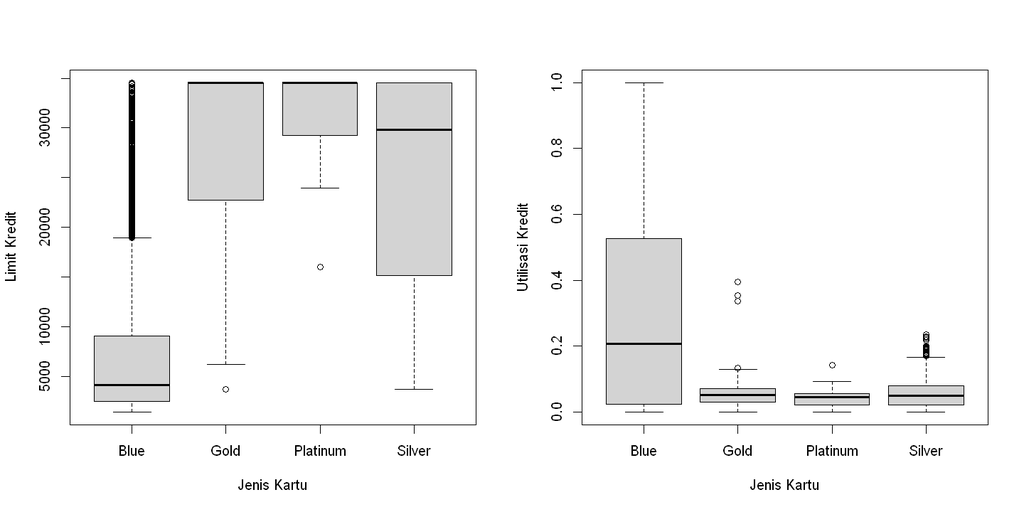

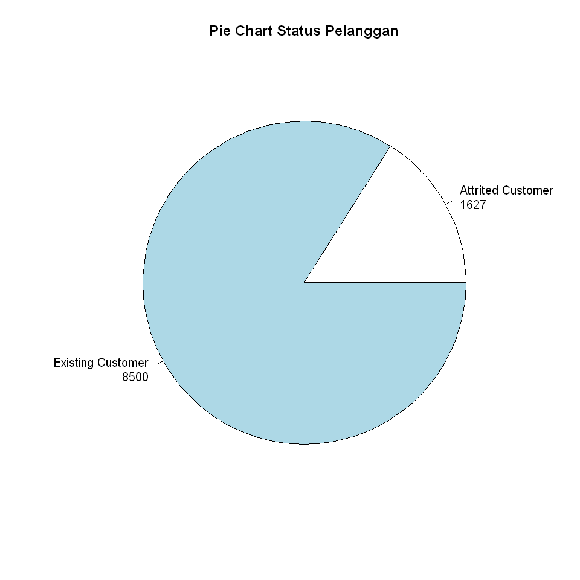

```r
options(repr.plot.width = 12, repr.plot.height = 6)
par(mfrow=c(1,2))
plot(factor(wr$Jenis_Kartu), wr$Limit_Kredit,
    xlab = "Jenis Kartu",
    ylab = "Limit Kredit")
plot(factor(wr$Jenis_Kartu), wr$Utilisasi,
    xlab = "Jenis Kartu",
    ylab = "Utilisasi Kredit")

par(mfrow=c(1,1))
options(repr.plot.width = 8, repr.plot.height = 8)
pie(table(wr$Status_Pelanggan),
    labels = paste(names(table(wr$Status_Pelanggan)), "\n", table(wr$Status_Pelanggan), sep=""),
    main = "Pie Chart Status Pelanggan")
```

Dari hasil boxplot diatas, kita bisa melihat bahwa adanya perbedaan yang signifikan dari kartu kredit berjenis Blue yang dengan utilisasi tertinggi dengan limit yang rendah. Yang artinya pengguna yang kurang mengutilisasi kartu kredit tersebut merupakan kartu Gold, Platnium, dan Silver. Pengguna Gold, Silver, dan Platinum sudah diberikan Limit Kredit yang tinggi hanya saja tidak di utilisasikan.

Utilisasi kredit adalah jumlah kredit yang digunakan / limit kredit.

Sebelum kita memfokuskan kepada kartu-kartu Gold, Platinum dan Silver, kita juga harus mencari tahu bagaimana orang-orang yang memiliki utilisasi yang rendah pada nasabah yang memiliki kartu Blue. Selain hal itu, kita juga akan memfokuskan kepada pengguna yang masih tercatat sebagai pelanggan.

#### Blue Card Data Exploration

```r
blue <- wr[(wr$Jenis_Kartu == "Blue"), ]
blue <- blue[(blue$Status_Pelanggan == "Existing Customer"), ]
head(blue)
descr(blue)
```

A data.frame: 6 × 12

|  | Status_Pelanggan <chr> | Waktu_Buku <int> | Umur_Pengguna <int> | Jenis_Kelamin <chr> | Jenis_Kartu <chr> | Tingkat_Pendidikan <chr> | Status_Pernikahan <chr> | Penghasilan <chr> | Limit_Kredit <dbl> | Besar_Transaksi <int> | Banyak_Transaksi <int> | Utilisasi <dbl> |
| --- | --- | --- | --- | --- | --- | --- | --- | --- | --- | --- | --- | --- |
| 1 | Existing Customer | 39 | 45 | M | Blue | High School | Married | $60K - $80K | 12691 | 1144 | 42 | 0.061 |
| 2 | Existing Customer | 44 | 49 | F | Blue | Graduate | Single | Less than $40K | 8256 | 1291 | 33 | 0.105 |
| 3 | Existing Customer | 36 | 51 | M | Blue | Graduate | Married | $80K - $120K | 3418 | 1887 | 20 | 0.000 |
| 4 | Existing Customer | 34 | 40 | F | Blue | High School | Unknown | Less than $40K | 3313 | 1171 | 20 | 0.760 |
| 5 | Existing Customer | 21 | 40 | M | Blue | Uneducated | Married | $60K - $80K | 4716 | 816 | 28 | 0.000 |
| 6 | Existing Customer | 36 | 44 | M | Blue | Graduate | Married | $40K - $60K | 4010 | 1088 | 24 | 0.311 |

A summarytools: 15 × 6 of type dbl

|  | Banyak_Transaksi | Besar_Transaksi | Limit_Kredit | Umur_Pengguna | Utilisasi | Waktu_Buku |
| --- | --- | --- | --- | --- | --- | --- |
| Mean | 67.82745990 | 4.469314e+03 | 7.468545e+03 | 46.31678666 | 0.31371353 | 35.91474043 |
| Std.Dev | 22.36562341 | 3.300602e+03 | 7.673216e+03 | 8.13896407 | 0.27423329 | 8.07044410 |
| Min | 11.00000000 | 8.160000e+02 | 1.438300e+03 | 26.00000000 | 0.00000000 | 13.00000000 |
| Q1 | 53.00000000 | 2.313000e+03 | 2.535000e+03 | 41.00000000 | 0.06600000 | 31.00000000 |
| Median | 70.00000000 | 4.086000e+03 | 4.163000e+03 | 46.00000000 | 0.24400000 | 36.00000000 |
| Q3 | 82.00000000 | 4.735000e+03 | 9.227000e+03 | 52.00000000 | 0.55200000 | 40.00000000 |
| Max | 139.00000000 | 1.848400e+04 | 3.451600e+04 | 73.00000000 | 0.99400000 | 56.00000000 |
| MAD | 19.27380000 | 1.362509e+03 | 3.157938e+03 | 8.89560000 | 0.34396320 | 7.41300000 |
| IQR | 29.00000000 | 2.422000e+03 | 6.692000e+03 | 11.00000000 | 0.48600000 | 9.00000000 |
| CV | 0.32974290 | 7.385030e-01 | 1.027404e+00 | 0.17572385 | 0.87415193 | 0.22471119 |
| Skewness | -0.03966578 | 2.175588e+00 | 1.916750e+00 | -0.03646988 | 0.49453783 | -0.10185206 |
| SE.Skewness | 0.02752409 | 2.752409e-02 | 2.752409e-02 | 0.02752409 | 0.02752409 | 0.02752409 |
| Kurtosis | -0.18558962 | 4.583927e+00 | 3.189027e+00 | -0.31618604 | -1.04548614 | 0.35342656 |
| N.Valid | 7917.00000000 | 7.917000e+03 | 7.917000e+03 | 7917.00000000 | 7917.00000000 | 7917.00000000 |
| Pct.Valid | 100.00000000 | 1.000000e+02 | 1.000000e+02 | 100.00000000 | 100.00000000 | 100.00000000 |

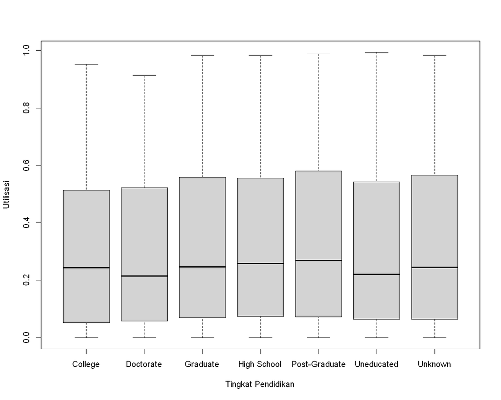

```r
options(repr.plot.width = 10, repr.plot.height = 8)
plot(factor(blue$Tingkat_Pendidikan), blue$Utilisasi,
     xlab = "Tingkat Pendidikan",
     ylab = "Utilisasi")
```

Dilihat dari boxplot diatas, status pendidikan tidak terlihat mempengaruhi utilisasi dari kartu kredit berjenis blue ini.

35.9147404319818

0.793746703104551

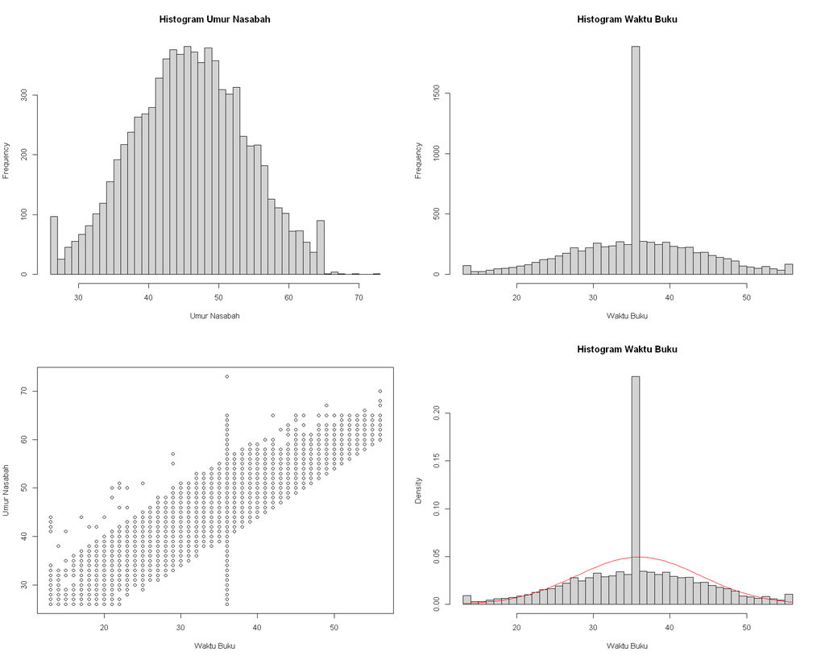

```r
mean(blue$Waktu_Buku)
cor(blue$Umur_Pengguna, blue$Waktu_Buku)

options(repr.plot.width = 15, repr.plot.height = 12)
par(mfrow=c(2,2))

hist(blue$Umur_Pengguna, breaks = 50,
     xlab = "Umur Nasabah", main = "Histogram Umur Nasabah")
hist(blue$Waktu_Buku, breaks = 50,
     xlab = "Waktu Buku", main = "Histogram Waktu Buku")

plot(blue$Waktu_Buku, blue$Umur_Pengguna,
     xlab = "Waktu Buku",
     ylab = "Umur Nasabah")

hist(blue$Waktu_Buku, breaks = 50, freq = FALSE,
     xlab = "Waktu Buku", main = "Histogram Waktu Buku")
curve(dnorm(x, mean = mean(blue$Waktu_Buku), sd = sd(blue$Waktu_Buku)), add = TRUE, col = "red")
```

Dari eksplorasi terhadap waktu buku yang ada, kami melihat adanya pelonjakan pendaftaran pada ±35 Bulan yang lalu atau sekitar, hampir 3 tahun yang lalu, bisa kita lihat dari histogram Waktu Buku. Dapat terlihat juga korelasi terhadap Umur Pengguna dengan Waktu Buku, hanya saja pada sekitaran Waktu Buku 35 bulan tersebut terlihat garis lurus bahwa adanya pelonjakan pendaftaran dari berbagai umur pada waktu tersebut.

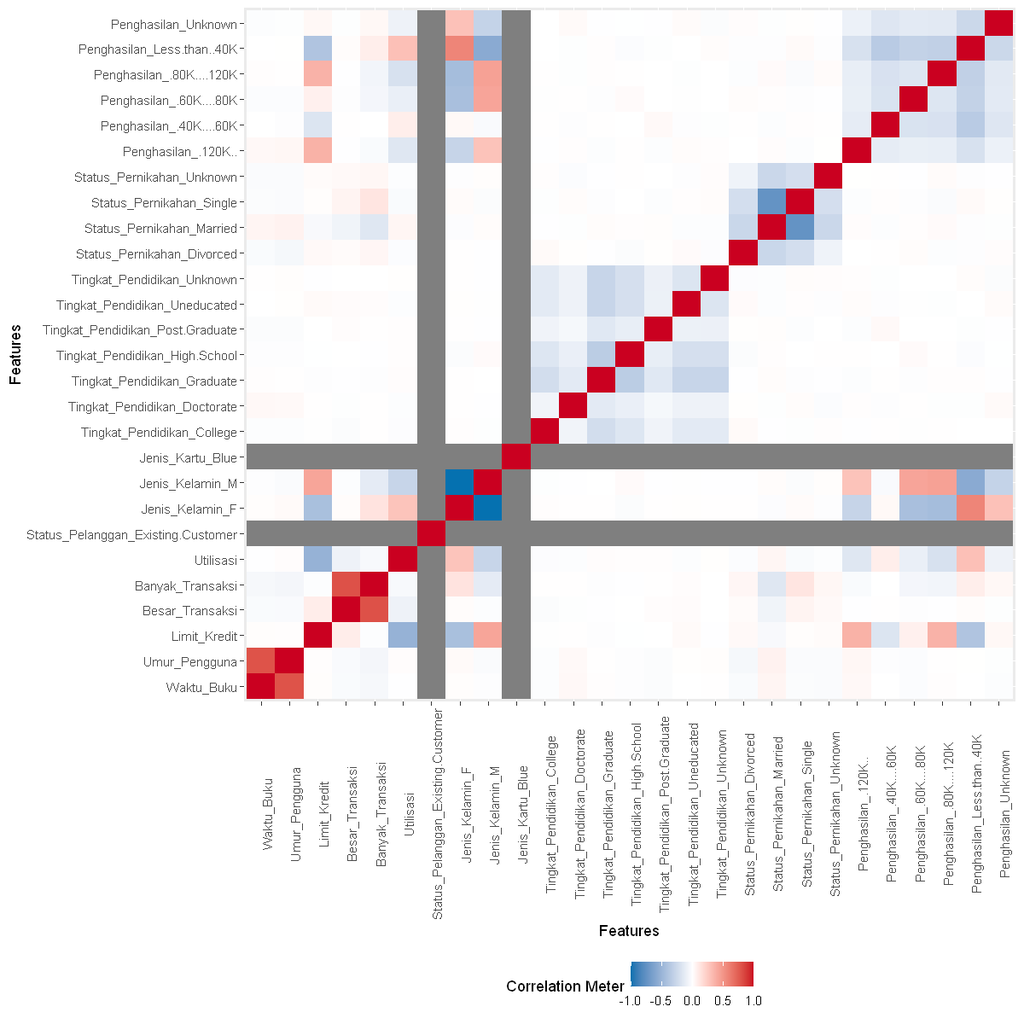

```r
options(repr.plot.width = 10, repr.plot.height = 10)
plot_correlation(blue)
```

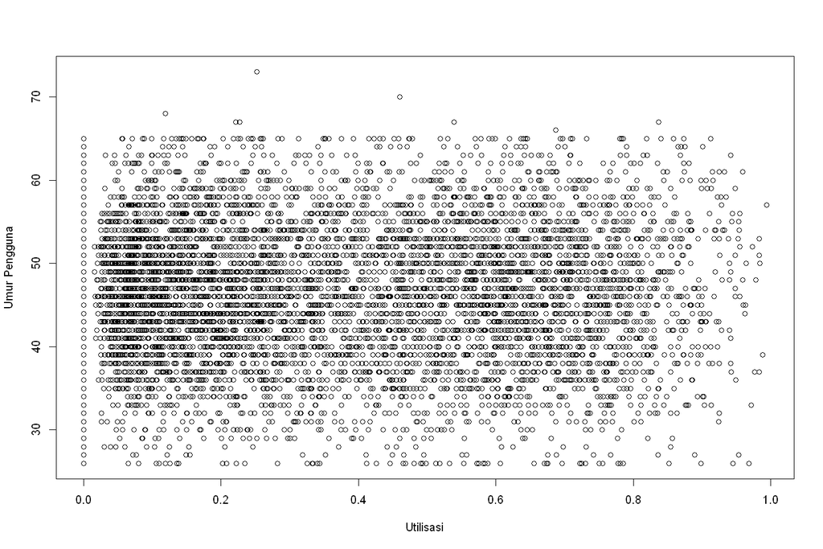

```r
options(repr.plot.width = 12, repr.plot.height = 8)
plot(blue$Utilisasi, blue$Umur_Pengguna,
     xlab = "Utilisasi", ylab = "Umur Pengguna")
```

Dari correlation diagram, terliat utilisasi memiliki korelasi negtif terhadap limit kredit. Ada beberapa informasi juga pada korelasi terhadap penghasilan, terlihat bahwa Penghasilan di atas \$60K dan penghasilan yang tidak diketahui memiliki korelasi negatif, sementara orang yang memiliki pendapatan di bawah \$60K memiliki korelasi positif.  
Dari diagram diatas juga terlihat bahwa banyak nasabah kita yang di sekitar umur 35-55, dan dari sana kita juga bisa melihat pada rentang-rentah umur tersebut banyak yang utilisasi di bawah rata-rata. Terlihat pada kepadatan dari scatter plot di atas.

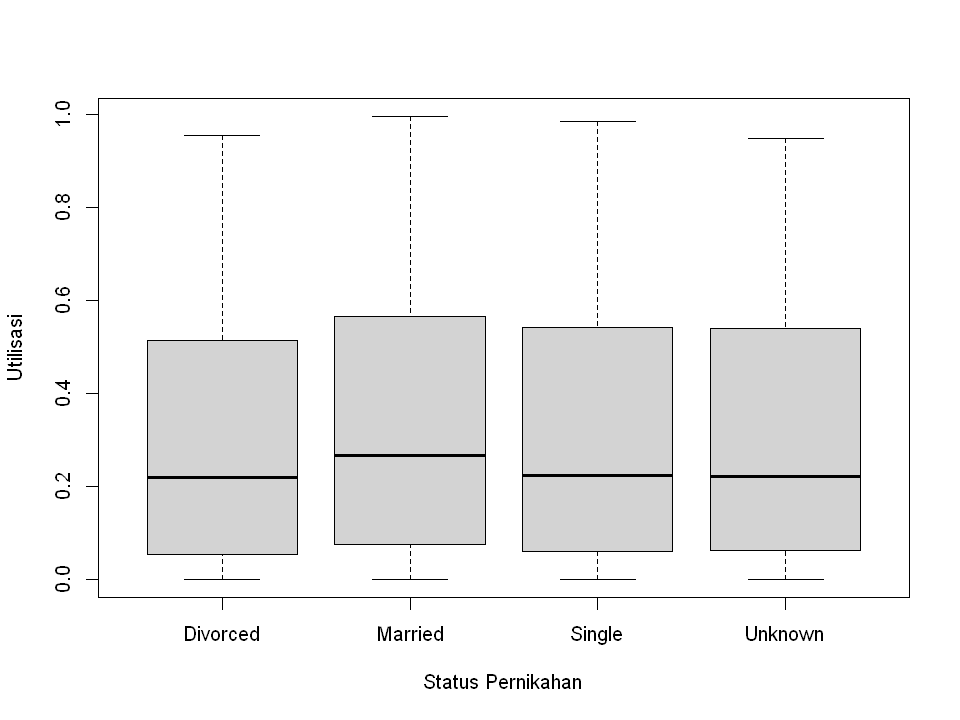

```r
options(repr.plot.width = 8, repr.plot.height = 6)
plot(factor(blue$Status_Pernikahan), blue$Utilisasi,
     xlab = "Status Pernikahan", ylab = "Utilisasi")
```

Dari status pernikahan, terlihat pada Q1 yang terendah terlihat pada orang-orang yang Divorced dan Single.

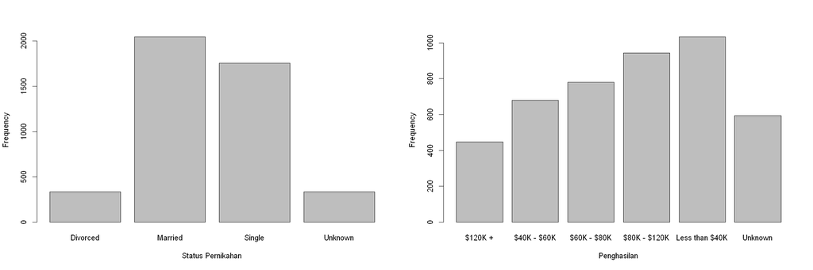

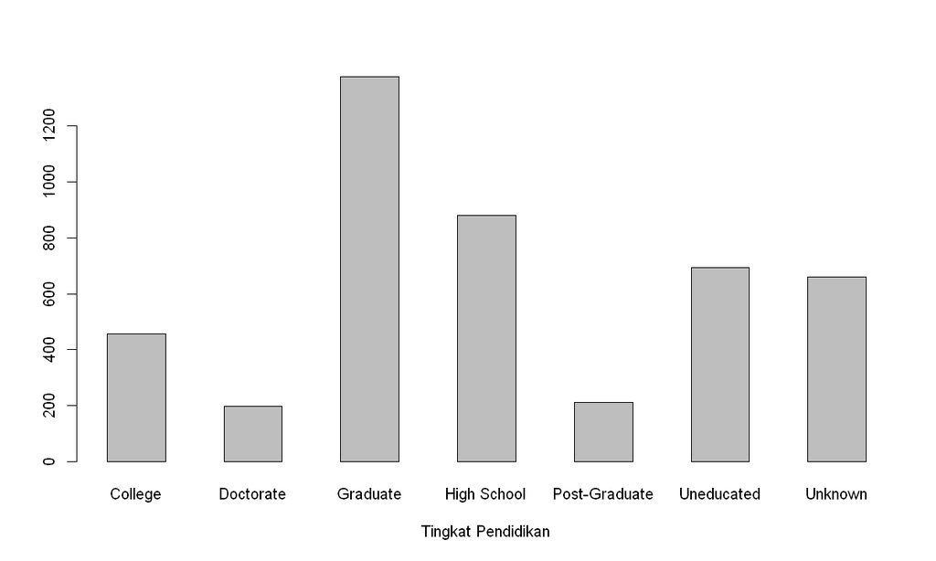

```r
temp <- blue[blue$Utilisasi <= mean(blue$Utilisasi),]

options(repr.plot.width = 18, repr.plot.height = 6)
par(mfrow=c(1,2))
barplot(table(temp$Status_Pernikahan), xlab = "Status Pernikahan", ylab = "Frequency")
barplot(table(temp$Penghasilan), xlab = "Penghasilan", ylab = "Frequency")
par(mfrow=c(1,1))
options(repr.plot.width = 10, repr.plot.height = 6)
barplot(table(temp$Tingkat_Pendidikan), space = TRUE, xlab = "Tingkat Pendidikan")
```

Dapat terlihat, pengguna kartu kategori Blue yang memiliki utilisasi yang di bawah rata-rata saat ini, dilihat dari status pernikahannya diantara Married atau Single. Jika dilihat dari tingkat pendidikannya, Graduate dan High School, dan jika dilihat jumlah pendapatan yang terlihat, orang yang memiliki pendapatan di bawah $40K meruapakan tipe orang yang memiliki utilisasi di bawah rata-rata.

#### Silver, Gold, and Platinum Card Data Exploration

```r
notblue <- wr[!(wr$Jenis_Kartu == "Blue"), ]
notblue <- notblue[(notblue$Status_Pelanggan == "Existing Customer"), ]
head(notblue)
descr(notblue)
```

A data.frame: 6 × 12

|  | Status_Pelanggan <chr> | Waktu_Buku <int> | Umur_Pengguna <int> | Jenis_Kelamin <chr> | Jenis_Kartu <chr> | Tingkat_Pendidikan <chr> | Status_Pernikahan <chr> | Penghasilan <chr> | Limit_Kredit <dbl> | Besar_Transaksi <int> | Banyak_Transaksi <int> | Utilisasi <dbl> |
| --- | --- | --- | --- | --- | --- | --- | --- | --- | --- | --- | --- | --- |
| 7 | Existing Customer | 46 | 51 | M | Gold | Unknown | Married | $120K + | 34516 | 1330 | 31 | 0.066 |
| 8 | Existing Customer | 27 | 32 | M | Silver | High School | Unknown | $60K - $80K | 29081 | 1538 | 36 | 0.048 |
| 38 | Existing Customer | 36 | 42 | F | Gold | High School | Married | Less than $40K | 15433 | 966 | 22 | 0.000 |
| 43 | Existing Customer | 43 | 50 | F | Silver | College | Single | $40K - $60K | 17304 | 1756 | 33 | 0.145 |
| 66 | Existing Customer | 38 | 51 | M | Silver | Uneducated | Single | $80K - $120K | 34516 | 1293 | 32 | 0.044 |
| 102 | Existing Customer | 34 | 41 | F | Silver | Unknown | Married | Unknown | 34516 | 1487 | 26 | 0.059 |

A summarytools: 15 × 6 of type dbl

|  | Banyak_Transaksi | Besar_Transaksi | Limit_Kredit | Umur_Pengguna | Utilisasi | Waktu_Buku |
| --- | --- | --- | --- | --- | --- | --- |
| Mean | 80.1492281 | 7171.5488851 | 25814.7324185 | 4.551973e+01 | 0.06145798 | 35.4168096 |
| Std.Dev | 26.9328431 | 5020.9515939 | 9509.4757342 | 7.216048e+00 | 0.05161493 | 7.3200890 |
| Min | 13.0000000 | 949.0000000 | 3735.0000000 | 2.600000e+01 | 0.00000000 | 13.0000000 |
| Q1 | 63.0000000 | 3299.0000000 | 15871.0000000 | 4.100000e+01 | 0.03200000 | 32.0000000 |
| Median | 79.0000000 | 4587.0000000 | 30899.0000000 | 4.500000e+01 | 0.05300000 | 36.0000000 |
| Q3 | 102.0000000 | 13021.0000000 | 34516.0000000 | 5.000000e+01 | 0.08000000 | 39.0000000 |
| Max | 134.0000000 | 17628.0000000 | 34516.0000000 | 6.500000e+01 | 0.39500000 | 56.0000000 |
| MAD | 28.1694000 | 4484.8650000 | 5362.5642000 | 5.930400e+00 | 0.03409980 | 4.4478000 |
| IQR | 39.0000000 | 9699.5000000 | 18616.5000000 | 9.000000e+00 | 0.04800000 | 7.0000000 |
| CV | 0.3360337 | 0.7001209 | 0.3683740 | 1.585257e-01 | 0.83984102 | 0.2066840 |
| Skewness | -0.1959234 | 0.5925698 | -0.4450258 | 8.342349e-03 | 1.73777798 | -0.1722743 |
| SE.Skewness | 0.1011878 | 0.1011878 | 0.1011878 | 1.011878e-01 | 0.10118779 | 0.1011878 |
| Kurtosis | -0.6704654 | -1.1669906 | -1.5120263 | 1.196709e-01 | 5.87326947 | 0.9542899 |
| N.Valid | 583.0000000 | 583.0000000 | 583.0000000 | 5.830000e+02 | 583.00000000 | 583.0000000 |
| Pct.Valid | 100.0000000 | 100.0000000 | 100.0000000 | 1.000000e+02 | 100.00000000 | 100.0000000 |

35.4168096054889

0.777221455062173

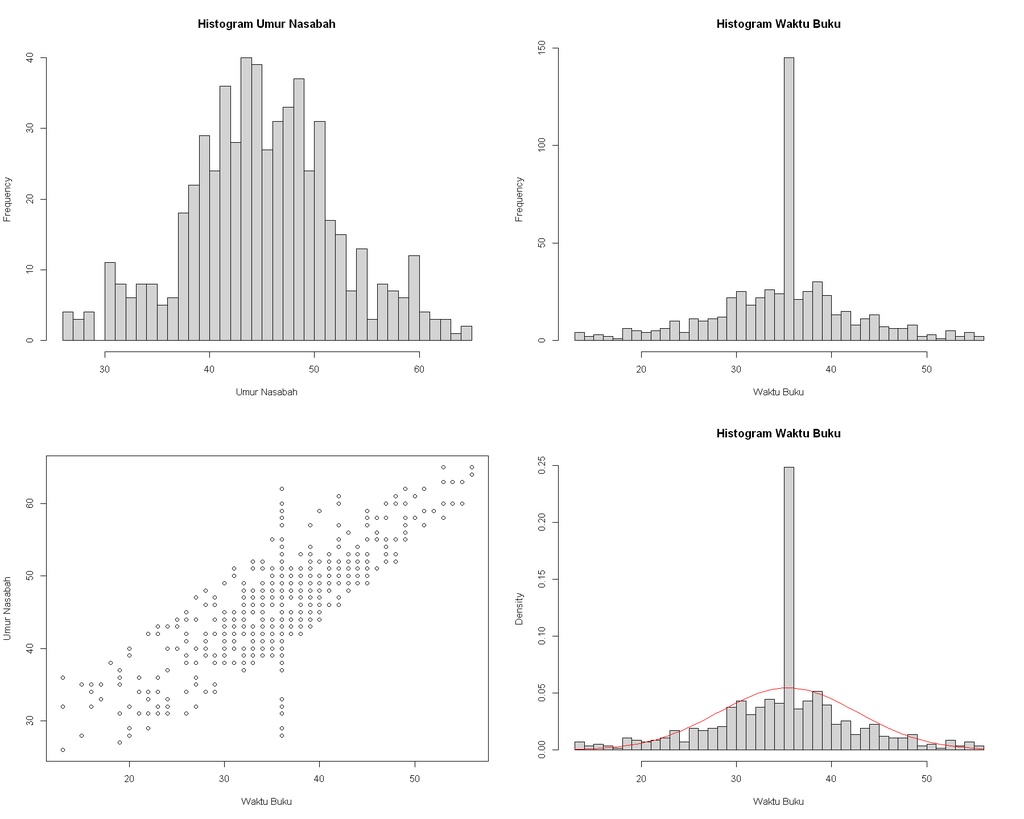

```r
mean(notblue$Waktu_Buku)
cor(notblue$Umur_Pengguna, notblue$Waktu_Buku)

options(repr.plot.width = 15, repr.plot.height = 12)
par(mfrow=c(2,2))

hist(notblue$Umur_Pengguna, breaks = 50,
     xlab = "Umur Nasabah", main = "Histogram Umur Nasabah")
hist(notblue$Waktu_Buku, breaks = 50,
     xlab = "Waktu Buku", main = "Histogram Waktu Buku")

plot(notblue$Waktu_Buku, notblue$Umur_Pengguna,
     xlab = "Waktu Buku",
     ylab = "Umur Nasabah")

hist(notblue$Waktu_Buku, breaks = 50, freq = FALSE,
     xlab = "Waktu Buku", main = "Histogram Waktu Buku")
curve(dnorm(x, mean = mean(notblue$Waktu_Buku), sd = sd(notblue$Waktu_Buku)), add = TRUE, col = "red")
```

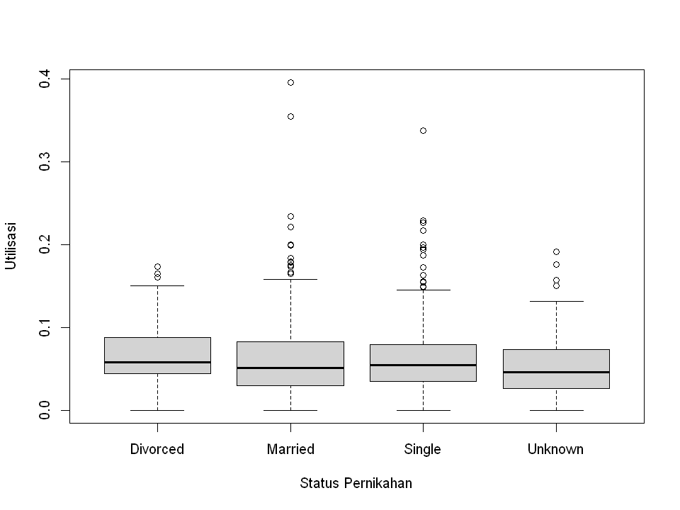

```r
options(repr.plot.width = 8, repr.plot.height = 6)
plot(factor(notblue$Status_Pernikahan), notblue$Utilisasi,
     xlab = "Status Pernikahan", ylab = "Utilisasi")
```

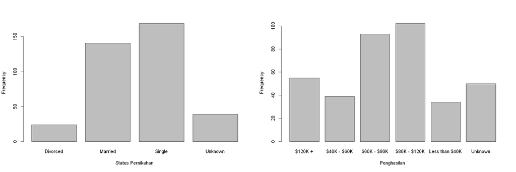

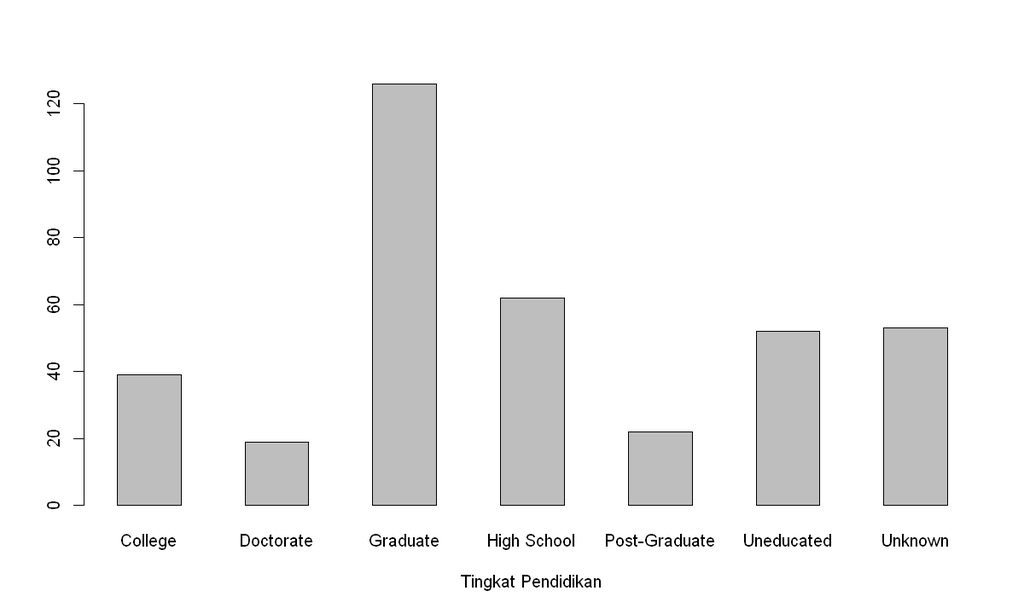

```r
temp <- notblue[notblue$Utilisasi <= mean(notblue$Utilisasi),]

options(repr.plot.width = 18, repr.plot.height = 6)
par(mfrow=c(1,2))
barplot(table(temp$Status_Pernikahan), xlab = "Status Pernikahan", ylab = "Frequency")
barplot(table(temp$Penghasilan), xlab = "Penghasilan", ylab = "Frequency")
par(mfrow=c(1,1))
options(repr.plot.width = 10, repr.plot.height = 6)
barplot(table(temp$Tingkat_Pendidikan), space = TRUE, xlab = "Tingkat Pendidikan")
```

Mirip dengan pengguna kartu berjenis blue, hanya saja pengguna dengan utilisasi dibawah rata-rata, saat ini untuk kartu selain biru ini cenderung nasabah yang memiliki penghasilan \$60K - \$120K

### Kesimpulan

Dari hasil eksplorasi data yang dilakukan, kita dapat mengetahui bahwa masih banyak orang yang masih tidak mengutilisasikan kartu kredit tersebut dan bisa kita lihat orang-orang yang memiliki utilisasi rendah. Pada kartu berjenis biru, pengguna yang sudah menikah dan single serta memiliki pendapatan <\$40K merupakan orang yang memiliki utilisasi yang rendah. Tidak jauh berbeda, kartu berjenis silver, gold, dan platinum memiliki nasabah dengan karakteristik yang sama dengan kartu berjenis blue, dimana nasabah-nasabah tersebut memiliki utilisasi yang rendah, hanya saja pada kartu berjenis selain blue ini orang yang memiliki pendapatan \$60K - \$120K merupakan orang yang memiliki utilisasi di bawah rata-rata.